# Introduction to Julia: Basic Types, Containers, and Control Flow

Author

David Evans

Published

March 30, 2026

# 1 Introduction

These notes cover the foundational building blocks of the Julia programming language. Julia is a high-level, high-performance language designed for technical computing. It combines the ease-of-use of languages like Python and R with the speed of compiled languages like C and Fortran. This makes it an increasingly popular choice in economics, statistics, and the computational sciences.

In this set of notes we will cover the following topics:

1. **Primitive data types** — the basic kinds of values Julia can work with (booleans, integers, floating-point numbers, and strings).
2. **Container types** — data structures that hold collections of values (arrays, tuples, named tuples, and dictionaries).
3. **Control flow** — tools for making decisions and repeating operations (comparisons, logical operators, `if` statements, and `for` loops).
4. **Functions** — how to package reusable code into named units with inputs and outputs, including an applied example from time series econometrics.
5. **Root solving** — how to use the `NonlinearSolve.jl` package to find zeros of nonlinear equations, with applications to CES market equilibrium.
6. **Optimization** — how to use the `Optim.jl` package to maximize and minimize functions, with applications to CES utility and profit maximization.
7. **Broadcasting** — Julia’s dot syntax for applying operations element-wise to arrays, with automatic loop fusion for performance.
8. **The type system** — abstract vs concrete types, type annotations, and multiple dispatch—the mechanism that makes Julia both flexible and fast.
9. **Worked example** — simulating an AR(1) process, combining types, arrays, loops, functions, and plotting into a complete application.

By the end of these notes you should be comfortable writing simple Julia programs that store data, iterate over collections, make decisions based on conditions, organize your code into reusable functions, and use packages for root solving and optimization.

# 2 Primitive Data Types

Every programming language has a set of **primitive data types**: the simplest kinds of values that everything else is built on top of. In Julia, the most important primitive types for everyday work are booleans, integers, and floating-point numbers. Understanding these types matters because Julia’s performance advantages come in large part from its type system: when the compiler knows exactly what kind of data it is working with, it can exploit it to generate fast machine code.

## 2.1 Booleans

A **boolean** is the simplest possible data type. It can take on exactly two values: `true` or `false`. Booleans arise naturally whenever we ask a yes-or-no question: *Is* $x$ greater than $y$? *Is this coefficient statistically significant?* *Has the optimization converged?* *Have we found an equilibrium?*

You can create a boolean directly or by evaluating an expression:

```julia
x = true        # Assign the boolean value true directly
y = 100 < 10    # Evaluate an expression; the result (false) is stored in y
```

```
false
```

We can verify the type of a variable using the built-in `typeof` function:

```julia
typeof(y)
```

```
Bool
```

The output `Bool` confirms that `y` is a boolean. We will see booleans again when we discuss comparisons and `if` statements later in these notes.

## 2.2 Integers

An **integer** is a whole number, i.e. any value from the set $\{\ldots, -3, -2, -1, 0, 1, 2, 3, \ldots\}$. Numbers like $0.5$ or $\pi$ are *not* integers. Integers are the natural choice whenever you are counting discrete quantities: the number of observations in a dataset, the index of an element in an array, or the number of iterations in a loop.

```julia
x = 3
y = 5
x + y
```

```
8
```

```julia
typeof(x)
```

```
Int64
```

The type `Int64` tells us that Julia is storing this integer using 64 bits of memory, which allows it to represent very large numbers (up to roughly $9.2 \times 10^{18}$).

### 2.2.1 Integer Division and the Remainder Operator

Division of two integers in Julia produces a floating-point result by default, which is the mathematically natural behavior:

```julia
x / y
```

```
0.6
```

Sometimes, however, we care about the **remainder** after integer division. The modulo operator `%` computes this:

```julia
5 % 3    # 5 divided by 3 is 1 remainder 2
```

```
2
```

```julia
51 % 17  # 51 is exactly divisible by 17, so the remainder is 0
```

```
0
```

The modulo operator is surprisingly useful in practice. For example, you can test whether a number is even by checking whether `n % 2 == 0`, or test divisibility more generally. We will use it later when we write a program to find prime numbers.

## 2.3 Floating-Point Numbers

Most numbers in economics are not integers. Prices, interest rates, GDP growth, and regression coefficients are all real-valued quantities that require decimal representation. Julia represents these using **floating-point numbers** (or “floats”), which are stored in the IEEE 754 double-precision format.

```julia
Pi = 3.14159265358979323846264
typeof(Pi)
```

```
Float64
```

The type `Float64` indicates a 64-bit floating-point number, which gives roughly 15–17 significant digits of precision. That there is a limited amount of precision can lead to numerical issues: for example if you add a very large number to a very small number you can run into rounding errors. This won’t be particularly relevant to this class but it is something to keep in mind as you work with computers. Julia also provides a built-in constant `pi` (with even higher precision through its `Irrational` type):

```julia
pi
```

```
π = 3.1415926535897...
```

### 2.3.1 Arithmetic with Floats

All the standard arithmetic operations work as you would expect:

```julia
pi * 4    # Multiplication
```

```
12.566370614359172
```

```julia
pi / 3    # Division
```

```
1.0471975511965976
```

Exponentiation uses the caret operator `^`:

```julia
2^4       # 2 raised to the 4th power
```

```
16
```

### 2.3.2 Ensuring a Value Is a Float

Sometimes you want to make sure Julia treats a number as a float rather than an integer. The simplest way to do this is to include a decimal point:

```julia
x = 3     # This is an Int64
y = 3.    # This is a Float64
typeof(x), typeof(y)
```

```
(Int64, Float64)
```

This distinction can matter for performance. When Julia knows a variable is a `Float64`, it can use the appropriate hardware instructions for floating-point arithmetic. Mixing types forces Julia to convert on the fly, which can slow things down in tight loops.

## 2.4 Strings

A **string** is a sequence of characters, used to represent text. In Julia, strings are created by enclosing text in double quotes:

```julia
greeting = "Hello, world!"
typeof(greeting)
```

```
String
```

Note that Julia uses double quotes `" "` for strings. Single quotes are reserved for individual **characters** (`Char` type), which is a distinct type:

```julia
c = 'A'
typeof(c)
```

```
Char
```

This is a common gotcha for people coming from Python, where single and double quotes are interchangeable.

### 2.4.1 String Operations

Julia provides a rich set of operations for working with strings. You can concatenate (join) strings using the `*` operator:

```julia
first_name = "David"
last_name = "Evans"
full_name = first_name * " " * last_name
```

```
"David Evans"
```

If you are used to Python or R, the use of `*` for concatenation may seem surprising. Julia chose `*` because string concatenation is not commutative ($\text{"ab"} \neq \text{"ba"}$), and `*` is the standard mathematical notation for non-commutative operations (like matrix multiplication).

You can also repeat a string using the `^` operator:

```julia
"ha" ^ 3
```

```
"hahaha"
```

### 2.4.2 String Interpolation

One of the most convenient features in Julia is **string interpolation**: embedding the value of an expression directly inside a string using the `$` sign:

```julia
name = "David"
age = 39
"My name is $name and I am $age years old."
```

```
"My name is David and I am 39 years old."
```

For more complex expressions, wrap them in parentheses:

```julia
x = 10
"The square of $x is $(x^2)."
```

```
"The square of 10 is 100."
```

String interpolation is much cleaner than manually concatenating strings with `*`, especially when building messages that include computed values. We will see this in action with `println("Element $i of letter_list is $letter")` in the `enumerate` example below.

### 2.4.3 Useful String Functions

Julia includes many built-in functions for working with strings:

```julia
s = "Economics is great"
length(s)              # Number of characters
```

```
18
```

```julia
uppercase(s)           # Convert to uppercase
```

```
"ECONOMICS IS GREAT"
```

```julia
occursin("great", s)   # Check if a substring is present
```

```
true
```

```julia
replace(s, "great" => "fascinating")   # Replace a substring
```

```
"Economics is fascinating"
```

```julia
split(s)               # Split on whitespace into an array of substrings
```

```
3-element Vector{SubString{String}}:
 "Economics"
 "is"
 "great"
```

The `split` function is particularly useful when parsing data files where fields are separated by spaces, commas, or other delimiters.

### 2.4.4 Converting Between Strings and Numbers

In data work you frequently need to convert between strings and numeric types. Use `parse` to convert a string to a number, and `string` to go the other direction:

```julia
parse(Int64, "42")         # String → Integer
```

```
42
```

```julia
parse(Float64, "3.14")     # String → Float
```

```
3.14
```

```julia
string(2.718)              # Number → String
```

```
"2.718"
```

The `parse` function will throw an error if the string cannot be interpreted as the requested type—for example, `parse(Int64, "hello")` would fail. This is useful as a built-in sanity check when reading data.

# 3 Container Types

Individual numbers are useful, but most real work involves collections of values. Julia provides several **container types** for grouping data together. We’ve already seen examples of containers come up: for example the `split(s)` function produced a Vector (Array). Each container type has different properties that make it suitable for different situations:

Summary of Julia’s main container types

| Container | Syntax | Mutable? | Access |
| --- | --- | --- | --- |
| **Array** | `[1, 2, 3]` | Yes | By index |
| **Tuple** | `(1, 2, 3)` | No | By index |
| **Named Tuple** | `(a=1, b=2)` | No | By name or index |
| **Dictionary** | `Dict("a" => 1)` | Yes | By key |

The key trade-offs are **mutability** (can you change the contents after creation?) and **access pattern** (do you look things up by position or by name?). Let us look at each in turn.

## 3.1 Arrays

An **array** is the workhorse container in Julia. It is an ordered, mutable collection of elements. “Ordered” means the elements have a definite sequence (first, second, third, …), and “mutable” means you can change, add, or remove elements after the array is created.

Arrays are created using square brackets:

```julia
David = [32, "male", 71.5]    # An array containing mixed types
typeof(David)
```

```
Vector{Any} (alias for Array{Any, 1})
```

The type `Vector{Any}` tells us two things: this is a one-dimensional array (a `Vector`), and it can hold elements of `Any` type. Julia determined this because the array contains an integer, a string, and a float—three different types.

### 3.1.1 Typed Arrays

When all the elements in an array share the same type, Julia can be much more efficient. It stores the data in a compact, contiguous block of memory and avoids the overhead of checking types at runtime:

```julia
Davidfloat = [32.1, 16., 35]
typeof(Davidfloat)
```

```
Vector{Float64} (alias for Array{Float64, 1})
```

Here Julia infers that every element is a `Float64`, so it creates a `Vector{Float64}`. If you try to insert a value of the wrong type, Julia will raise an error:

```julia
Davidfloat[2] = "test"    # Cannot assign a String to a Float64 array
```

```
MethodError: Cannot `convert` an object of type String to an object of type Float64
The function `convert` exists, but no method is defined for this combination of argument types.

Closest candidates are:
  convert(::Type{T}, ::T) where T<:Number
   @ Base number.jl:6
  convert(::Type{T}, ::Number) where T<:Number
   @ Base number.jl:7
  convert(::Type{T}, ::T) where T
   @ Base Base_compiler.jl:133
  ...

Stacktrace:
 [1] setindex!(A::Vector{Float64}, x::String, i::Int64)
   @ Base ./array.jl:985
 [2] top-level scope
   @ ~/University of Oregon Dropbox/David Evans/University of Oregon/Courses/Spring 2026/EC 410/Lectures and Website/Julia/Basic Julia/JuliaBasicsNotes.qmd:287
```

In performance-critical code (e.g., numerical simulations, optimization routines), you should try to use typed arrays whenever possible.

### 3.1.2 Accessing and Modifying Arrays

You access elements of an array using square-bracket indexing:

```julia
David[2]    # Access the second element
```

```
"male"
```

Because arrays are mutable, you can change existing elements and append new ones:

```julia
David[3] = David[3] / 12      # Modify the third element
push!(David, 12)               # Append a new element to the end
David
```

```
4-element Vector{Any}:
 32
   "male"
  5.958333333333333
 12
```

Note the exclamation mark in `push!`. In Julia, function names ending with `!` follow a convention indicating that the function **modifies its argument in place** rather than returning a new copy. This is an important idiom you will see throughout the language.

### 3.1.3 Indexing: Julia Starts at 1

**ImportantJulia is 1-indexed!**

Unlike Python and C (which start at 0), Julia arrays start at index 1. This is a common source of bugs when switching between languages. The first element is `L[1]`, not `L[0]`.

Here are the key indexing conventions:

- `L[1]` — the first element
- `L[i]` — the element at position $i$
- `L[end]` — the last element
- `L[end-1]` — the second-to-last element

The `end` keyword is particularly convenient because it saves you from having to compute the length of the array.

### 3.1.4 Array Slicing

You can extract a contiguous subset of an array using the colon `:` operator. The expression `L[a:b]` returns a new array containing elements at positions $a, a+1, \ldots, b$:

```julia
print(David[1:3])    # Equivalent to David[1:end-1] in this case
```

```
Any[32, "male", 5.958333333333333]
```

Slicing is useful for extracting subsets of data—for example, taking the first $n$ observations from a dataset, or splitting a time series into training and test sets.

## 3.2 Tuples

A **tuple** is similar to an array in that it holds an ordered collection of elements, but with one critical difference: tuples are **immutable**. Once created, their contents cannot be changed. This makes tuples useful for representing fixed collections of values—things that should not accidentally be modified.

Tuples are created using parentheses (or simply by separating values with commas):

```julia
d = (39, "male", 71.5)      # Parentheses notation
d = 39, "male", 71.5        # Equivalent: comma-separated values
print(typeof(d))
```

```
Tuple{Int64, String, Float64}
```

Notice that Julia tracks the type of each element individually. The type `Tuple{Int64, String, Float64}` tells us exactly what is in each position.

Attempting to modify a tuple produces an error:

```julia
d[1] = 5    # Tuples are immutable!
```

```
MethodError: no method matching setindex!(::Tuple{Int64, String, Float64}, ::Int64, ::Int64)
The function `setindex!` exists, but no method is defined for this combination of argument types.
Stacktrace:
 [1] top-level scope
   @ ~/University of Oregon Dropbox/David Evans/University of Oregon/Courses/Spring 2026/EC 410/Lectures and Website/Julia/Basic Julia/JuliaBasicsNotes.qmd:355
```

### 3.2.1 Tuple Unpacking

One of the most useful features of tuples is **unpacking**: assigning each element of a tuple to a separate variable in a single statement:

```julia
integers = (4, 5, 6)
x, y, z = integers
x
```

```
4
```

```julia
z
```

```
6
```

This works with arrays too:

```julia
x, y, z = David    # Unpacks the first three elements
x
```

```
32
```

Tuple unpacking is especially handy when a function returns multiple values. For example, a function that performs a statistical test might return both the test statistic and the p-value as a tuple, and you can unpack them directly into named variables.

### 3.2.2 Named Tuples

**Named tuples** combine the immutability of regular tuples with the readability of named access. Instead of remembering that the age is at position 1 and the height is at position 3, you can access fields by name:

```julia
person = (name="David", age=39, height=71.5)
typeof(person)
```

```
@NamedTuple{name::String, age::Int64, height::Float64}
```

```julia
person.name       # Access by name (preferred for readability)
```

```
"David"
```

```julia
person[1]         # Can still access by index if needed
```

```
"David"
```

**TipWhen to Use Named Tuples**

Named tuples are ideal when you want to return multiple values from a function with descriptive labels. They are lightweight (no need to define a `struct`, we’ll talk about this later) and self-documenting. For example, a calibration function might return `(β=0.96, σ=2.0, δ=0.025)` so the caller immediately knows which parameter is which.

## 3.3 Dictionaries

A **dictionary** (or `Dict`) is a mutable container that maps **keys** to **values**. Unlike arrays and tuples, dictionaries are not ordered by position—instead, you look up values by their key. This makes dictionaries ideal when you need to associate labels with data.

```julia
David = Dict("age" => 39, "gender" => "male", "height" => 71.5)
print(typeof(David))
```

```
Dict{String, Any}
```

```julia
David["age"]    # Look up a value by its key
```

```
39
```

### 3.3.1 Adding and Modifying Entries

Because dictionaries are mutable, you can add new key-value pairs or change existing ones:

```julia
David["job"] = "Economist"
David["job"]
```

```
"Economist"
```

In the dictionary above, `"age"`, `"gender"`, `"height"`, and `"job"` are the **keys**, and `39`, `"male"`, `71.5`, and `"Economist"` are the corresponding **values**.

Dictionaries are especially useful when dealing with structured data where positional indexing would be confusing. Imagine an array with 20 elements—was the interest rate at position 7 or position 12? With a dictionary you simply write `params["interest_rate"]` and the code is self-documenting.

### 3.3.2 Choosing the Right Container

To summarize, here are some rules of thumb:

- **Use an array** when you have an ordered collection of items that may need to change, especially if all elements are the same type (for performance).
- **Use a tuple** when you have a small, fixed collection that should not change—for example, the return values of a function.
- **Use a named tuple** when you want immutable data with descriptive field names.
- **Use a dictionary** when you need to look up values by a meaningful key rather than by position.

# 4 Iteration with For Loops

Much of computational economics involves repeating an operation many times: simulating an economy for $T$ periods, computing a sum over $N$ observations, or iterating on a value function until convergence. The **for loop** is the basic tool for this kind of repetition.

## 4.1 Basic For Loop Syntax

The general form of a `for` loop in Julia is:

```julia
for variable in iterable
    # code that may depend on variable
end
```

The **iterable** is any object Julia can step through one element at a time—an array, a tuple, a range like `1:10`, and so on. For each element in the iterable, Julia executes the code inside the loop with `variable` set to the current element.

Here is a simple example:

```julia
for i in 1:5
    println(i)
end
```

```
1
2
3
4
5
```

The expression `1:5` creates a **range** object representing the sequence $1, 2, 3, 4, 5$. The loop variable `i` takes on each value in turn, and `println` prints it followed by a newline. You can think of code like this a *rolling* out a sequence of lines of code

```julia
println(1) #i=1
println(2) #i=2
println(3) #i=3
println(4) #i=4
println(5) #i=5
```

```
1
2
3
4
5
```

but often times there are additional optimizations the compiler can run behind the scenes that you don’t have to worry about.

We can put any code we like inside the loop body:

```julia
for i in 1:5
    x = i^2
    println(x)
end
```

```
1
4
9
16
25
```

## 4.2 Looping Over Collections

For loops are not limited to numeric ranges. You can loop directly over the elements of any collection:

```julia
David = [32, "male", 71.5];    # Semicolon suppresses output
for element in David
    println(element)
end
```

```
32
male
71.5
```

This style—iterating over elements directly rather than over indices—is considered more idiomatic in Julia and tends to produce cleaner, more readable code:

```julia
x_values = [4, 2, 3]
for x in x_values
    println(x * x)
end
```

```
16
4
9
```

Compare that with the index-based alternative, which is more verbose and harder to read:

```julia
for i in 1:length(x_values)
    println(x_values[i] * x_values[i])
end
```

```
16
4
9
```

Both produce the same result, but the first version communicates intent more clearly: “for each value in the list, print its square.”

## 4.3 Using `enumerate` for Index-Value Pairs

Sometimes you need both the index *and* the value during iteration. Rather than managing a counter variable yourself, Julia provides the `enumerate` function:

**TipBest Practice**

Use `enumerate` when you need both the index and the value. It is cleaner and less error-prone than managing a separate counter.

```julia
letter_list = ['a', 'b', 'c']
for (i, letter) in enumerate(letter_list)
    println("Element $i of letter_list is $letter")
end
```

```
Element 1 of letter_list is a
Element 2 of letter_list is b
Element 3 of letter_list is c
```

Notice the use of **string interpolation** with the `$` sign: inside a string, `$i` is replaced by the value of `i`. This is a convenient Julia feature for building formatted output.

## 4.4 Example: Computing an Inner Product

A common operation in economics and statistics is the **inner product** (or dot product) of two vectors. Given $x = [x_1, \ldots, x_n]$ and $y = [y_1, \ldots, y_n]$, the inner product is:

$$\langle x, y \rangle = \sum_{i=1}^{n} x_i \cdot y_i$$

Here is how you might compute it with a for loop:

```julia
x = [3, 57, 2, 1, 8, 5]
y = [4.3, 23, 2, 47, 42, 6]
ret = 0.0
for i in 1:length(x)
    ret = ret + x[i] * y[i]    # Equivalently: ret += x[i] * y[i]
end
ret
```

```
1740.9
```

Note that we initialize `ret = 0.0` (a float) rather than `ret = 0` (an integer). This ensures the accumulator has the right type from the start, avoiding a type conversion partway through the loop.

(In practice, Julia provides built-in functions for this—`dot(x, y)` from the `LinearAlgebra` standard library—but it is instructive to see how you would implement it yourself.)

## 4.5 Example: Computing a Geometric Sum

In macroeconomics, the geometric sum appears frequently when computing present discounted values. Given a discount factor $\beta \in (0,1)$, the sum:

$$S = \sum_{j=0}^{50} \beta^j$$

can be computed as follows:

```julia
β = 0.95    # Type \beta then press Tab to get the Greek letter
ret = 0.0
for j in 0:50
    ret += β^j
end
print(ret)
```

```
18.538045469742436
```

**TipGreek Letters in Julia**

Julia supports Unicode identifiers, which means you can use Greek letters in your code. To type `β`, enter `\beta` and press `Tab` in the Julia REPL or a Jupyter/Quarto code cell. This makes your code look much closer to the mathematical notation—a significant readability advantage over languages that restrict you to ASCII variable names.

# 5 Comparisons and Logical Operators

Now that we know how to store data and iterate, the next step is making **decisions**—executing different code depending on whether a condition is true or false. This requires two ingredients: comparisons (which produce boolean values) and logical operators (which combine boolean values).

## 5.1 Comparison Operators

Julia provides the standard comparison operators you would expect from mathematics:

| Operator | Meaning |
| --- | --- |
| `<` | Less than |
| `>` | Greater than |
| `<=` | Less than or equal to |
| `>=` | Greater than or equal to |
| `==` | Equal to |
| `!=` | Not equal to |

Each comparison returns a boolean:

```julia
x, y = 1, 2
x < y
```

```
true
```

```julia
x > y
```

```
false
```

### 5.1.1 Chained Comparisons

A particularly nice feature of Julia is that you can **chain comparisons**, just as you would in mathematical notation. The expression `a < b < c` is equivalent to `a < b && b < c`, but more readable:

```julia
1 < 2 < 3
```

```
true
```

```julia
1 <= 2 <= 3 > 4
```

```
false
```

This is very handy for checking whether a value falls within a range: `0 < x < 1` reads naturally as “$x$ is between 0 and 1.”

### 5.1.2 Assignment vs. Equality

**WarningCommon Mistake**

Do not confuse `=` (assignment) with `==` (equality test). Writing `x = 2` *sets* `x` to 2, while `x == 2` *asks* whether `x` is equal to 2. This is an easy mistake to make early on.

```julia
x = 1       # Assignment: x is now 1
x == 2      # Equality test: is x equal to 2?
```

```
false
```

```julia
x != 2      # Inequality test: is x NOT equal to 2?
```

```
true
```

## 5.2 Logical Operators

Logical operators let you combine multiple boolean expressions into a single condition. Julia uses the following syntax:

| Expression | Meaning | Result |
| --- | --- | --- |
| `P && Q` | Logical AND | `true` only if **both** `P` and `Q` are `true` |
| `P \\|\\| Q` | Logical OR | `true` if **at least one** of `P` or `Q` is `true` |
| `!P` | Logical NOT | Negates `P`: `true` becomes `false` and vice versa |

### 5.2.1 Logical AND (`&&`)

The `&&` operator returns `true` only when both sides are `true`:

```julia
1 < 2 && 'f' in "foo"    # Both true → true
```

```
true
```

```julia
1 < 2 && 'g' in "foo"    # Second is false → false
```

```
false
```

### 5.2.2 Logical OR (`||`)

The `||` operator returns `true` when at least one side is `true`:

```julia
1 < 2 || 'g' in "foo"    # First is true → true (second doesn't matter)
```

```
true
```

Julia uses **short-circuit evaluation** for both `&&` and `||`. For `&&`, if the first operand is `false`, Julia does not even evaluate the second (since the result must be `false` regardless). For `||`, if the first operand is `true`, the second is skipped. This can improve performance and is also used as a control-flow idiom in Julia.

### 5.2.3 Logical NOT (`!`)

The `!` operator simply flips a boolean value:

```julia
!true
```

```
false
```

```julia
!!true    # Double negation returns the original value
```

```
true
```

# 6 Conditional Execution with If Statements

Comparisons and logical operators become truly powerful when combined with **conditional statements**. An `if` statement lets you execute a block of code only when a specified condition holds.

## 6.1 Basic If Statement

The simplest form is:

```julia
if condition
    # code to execute when condition is true
end
```

```julia
x = 5
if x > 4
    println("Yay!")
end
```

```
Yay!
```

If the condition evaluates to `false`, the code block is simply skipped:

```julia
if x < 4
    println("This code never runs.")
end
```

Nothing is printed, because `5 < 4` is `false`.

## 6.2 If-Else Statements

Often you want to do one thing when a condition is true and something else when it is false. The `else` clause handles this:

```julia
x = Int[]    # Initialize an empty array of integers
for i in 1:10
    if 3 <= i <= 7
        push!(x, i^2)     # Square the value if i is between 3 and 7
    else
        push!(x, i)       # Otherwise, just use i as-is
    end
end
```

```julia
println(x)
```

```
[1, 2, 9, 16, 25, 36, 49, 8, 9, 10]
```

Notice how the chained comparison `3 <= i <= 7` makes the condition easy to read. The resulting array contains the original values for $i \in \{1,2,8,9,10\}$ and the squared values for $i \in \{3,4,5,6,7\}$.

Julia also supports `elseif` for checking multiple conditions in sequence:

```julia
if condition1
    # code for condition1
elseif condition2
    # code for condition2
else
    # code if neither condition is met
end
```

## 6.3 Example: Finding Prime Numbers

Let us put everything together with a more substantial example: finding all prime numbers from 2 to 500. A prime number is a natural number greater than 1 that is divisible only by 1 and itself. The algorithm below uses a straightforward approach: for each candidate number, check whether any previously found prime divides it evenly.

```julia
primes = Int[]                    # Initialize an empty array of integers
for i in 2:500                    # Loop through candidate numbers
    isprime = true                # Assume i is prime until proven otherwise
    for p in primes               # Check each known prime
        if i % p == 0             # If p divides i evenly...
            isprime = false       # ...then i is not prime
        end
    end
    if isprime                    # If no known prime divided i...
        push!(primes, i)          # ...then i is prime; add it to our list
    end
end
print(primes)
```

```
[2, 3, 5, 7, 11, 13, 17, 19, 23, 29  …  443, 449, 457, 461, 463, 467, 479, 487, 491, 499]
```

This example uses nearly every concept from these notes:

- **An array** (`primes`) to store the results, with `push!` to grow it dynamically.
- **Nested for loops** to iterate over candidates and known primes.
- **The modulo operator** (`%`) to test divisibility.
- **An if statement** to conditionally classify each number.
- **A boolean variable** (`isprime`) to track the result of the divisibility checks.

While this algorithm is not the most efficient way to find primes (a Sieve of Eratosthenes would be faster), it illustrates how simple programming constructs combine to solve a nontrivial problem.

# 7 Functions

So far we have been writing code as a sequence of statements: one after another, top to bottom. This works for small scripts, but as programs grow it quickly becomes unwieldy. **Functions** solve this problem by letting you package a piece of code into a reusable, named unit that takes inputs and produces outputs. Functions are arguably the single most important organizational tool in programming. They are also the secret sauce in julia: julia optimizes functions by compiling them into machine code.

There are several reasons to use functions:

- **Avoid repetition.** If you need to perform the same computation in multiple places, write it once as a function and call it wherever you need it.
- **Manage complexity.** Functions let you break a large problem into small, understandable pieces. Each function does one thing, and you can reason about it in isolation.
- **Improve readability.** A well-named function call like `simulateAR1(0.0, 100)` communicates intent far more clearly than the 10 lines of loop code it encapsulates.
- **Enable testing.** You can test each function independently to make sure it works correctly before combining them.

Julia’s functions are very flexible. Any object can be passed as an argument, even other functions! Functions can return any kind of object, including other functions. And any number of functions can be defined in a single file.

## 7.1 Anonymous (Lambda) Functions

The simplest way to create a function in Julia is the **arrow syntax**:

```julia
f = x -> x^2
f(2)
```

```
4
```

```julia
f(3)
```

```
9
```

Here `x -> x^2` creates an **anonymous function** (also called a lambda function): a function with no name. We then assign it to the variable `f` so we can call it later. Anonymous functions are especially useful when you need a short, throwaway function—for example, as an argument to `map`, `filter`, or `sort`.

## 7.2 Short-Form Function Definition

For simple one-line functions that you want to give a name to, Julia provides a compact **assignment form**:

```julia
g(x) = x^2
g(5)
```

```
25
```

This is equivalent to writing `g = x -> x^2`, but reads more naturally. You will see this style used frequently for mathematical functions that can be expressed in a single expression.

## 7.3 Multi-Line Functions with `function`

For anything more than a single expression, use the `function` keyword:

```julia
function h(x)
    return x^2
end
h(pi)
```

```
9.869604401089358
```

The `return` keyword specifies what value the function gives back to the caller. If you omit `return`, Julia automatically returns the value of the last expression evaluated in the function body. While this implicit return is convenient for short functions, using `return` explicitly is good practice for clarity, especially in longer functions.

## 7.4 Default Arguments

You can give function arguments **default values**, making them optional when the function is called:

```julia
function greet(name, greeting="Hello")
    println("$greeting, $(name)!")
end
greet("David")
```

```
Hello, David!
```

```julia
greet("David", "Howdy")
```

```
Howdy, David!
```

Default arguments are specified with `=` in the function signature. When the caller omits that argument, the default is used. This is particularly useful for parameters that have a “standard” value but occasionally need to be overridden—like the persistence parameter in a time series model, or the tolerance in an optimization routine.

## 7.5 Multiple Return Values

Functions can return multiple values by returning a tuple. The caller can then unpack the results:

```julia
function divide(a, b)
    quotient = a ÷ b     # integer division
    remainder = a % b
    return quotient, remainder
end
q, r = divide(17, 5)
println("17 ÷ 5 = $q remainder $r")
```

```
17 ÷ 5 = 3 remainder 2
```

This pattern is extremely common in scientific computing. For example, a function that estimates a regression model might return both the coefficient vector and the standard errors. Recall from our earlier discussion that named tuples are an even more readable way to return multiple values: `return (coef=β, se=σ)`.

## 7.6 Docstrings

Julia supports **docstrings**—documentation strings placed immediately before a function definition. These serve as built-in documentation that can be accessed from the REPL using `?`:

```julia
"""
    square(x)

Return the square of `x`.
"""
function square(x)
    return x^2
end
```

```
Main.Notebook.square
```

Writing docstrings is a good habit. They make your code self-documenting and help both your collaborators and your future self understand what each function does, what arguments it expects, and what it returns.

## 7.7 Application: Simulating an AR(1) Process

Let us put functions to work with an example from time series econometrics. An **AR(1) process** (first-order autoregressive process) is defined by:

$$x_{t} = \rho x_{t-1} + \epsilon_{t} \quad\text{where}\quad \epsilon_{t} \sim \mathcal{N}(0,1)$$

Here $x_t$ is a random variable at time $t$. Its value depends on the previous period’s value $x_{t-1}$ (scaled by the persistence parameter $\rho$) plus a random shock $\epsilon_t$ drawn from a standard normal distribution. AR(1) processes are ubiquitous in macroeconomics and finance—they are used to model productivity shocks, income processes, interest rates, and many other time series.

### 7.7.1 Building Up: Random Numbers

Before writing the full simulation function, let us see how Julia generates random numbers. The `randn()` function draws from the standard normal distribution $\mathcal{N}(0,1)$:

```julia
println(randn())
println(randn())
println(randn())
```

```
0.5823714071281189
-0.37028314179894617
-1.0187146419647202
```

You can also generate an entire array of random numbers at once:

```julia
randn(5)
```

```
5-element Vector{Float64}:
 -1.9550833235826852
  1.318778505892125
 -1.1540191806490612
  1.4015403045706611
  2.080821559546796
```

### 7.7.2 Building Up: A Single Step

If $x_{t-1} = 5$ and $\rho = 0.8$, a single step of the AR(1) process looks like:

```julia
x = 5.0
ρ = 0.8
print(ρ * x + randn())
```

```
3.130730344453524
```

### 7.7.3 Multiple Periods with a For Loop

Now let us simulate multiple periods. Starting from $x_1 = 5$ with $\rho = 0.8$, we simulate $T = 10$ periods by pre-allocating an array and filling it in with a for loop:

```julia
T = 10
x = zeros(T)       # pre-allocate array of zeros
x[1] = 5.0         # set initial condition
ρ = 0.8

# simulate using a for loop
for t in 2:T
    x[t] = ρ * x[t-1] + randn()    # update using previous period's value
end

@show x;
```

```
x = [5.0, 1.9901403891536105, 1.0628777341184208, 0.42537370890233284, -1.028302628752003, -0.7875900096614094, 0.45060446339243265, -1.0033683897154098, 1.3682017097539751, 0.28429685684561756]
```

Each iteration updates $x_t = \rho \, x_{t-1} + \varepsilon_t$. Because $|\rho| < 1$, the series **mean-reverts** toward zero: large deviations are pulled back, and the long-run average is zero regardless of the initial condition.

### 7.7.4 Plotting the Results

We can visualize the simulated path using `Plots.jl`:

```julia
using Plots
```

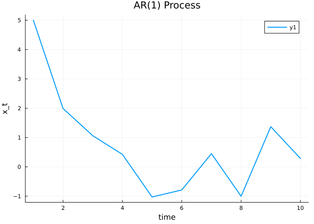

```julia
plot(x, linewidth=2)
xlabel!("time")
ylabel!("x_t")
title!("AR(1) Process")
```

The `xlabel!`, `ylabel!`, and `title!` functions modify the current plot in place (note the `!` convention). We will use `Plots.jl` extensively throughout this course.

### 7.7.5 The Simulation Function

Now we can wrap the full simulation into a function. Notice how it uses several concepts we have covered: arrays, for loops, default arguments, and a docstring:

```julia
"""
    simulateAR1(x0, T, ρ=0.8)

Simulate `T` periods of the AR(1) process xₜ = ρ*xₜ₋₁ + εₜ
where εₜ ~ N(0,1).

# Arguments
- `x0`: initial value for x
- `T`: number of periods to simulate
- `ρ`: persistence parameter (default 0.8)

# Returns
- Vector of length `T` containing the simulated path
"""
function simulateAR1(x0, T, ρ=0.8)
    x = zeros(T)       # Pre-allocate array
    x[1] = x0          # Set initial condition
    for t in 2:T
        x[t] = ρ * x[t-1] + randn()
    end
    return x
end
```

```
Main.Notebook.simulateAR1
```

A few things to note about this function:

- The array is **pre-allocated** with `zeros(T)` rather than grown incrementally with `push!`. This is much more efficient for numerical work because Julia can allocate a single contiguous block of memory up front.
- The default value `ρ=0.8` means the caller can simply write `simulateAR1(0.0, 100)` for the most common case.
- The docstring documents the arguments and return value, following Julia conventions.

### 7.7.6 Using the Function

Now we can simulate and plot paths for different values of $\rho$:

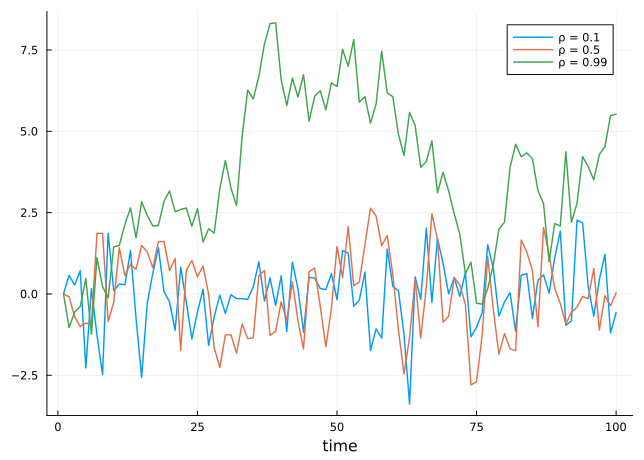

```julia
plot(simulateAR1(0., 100, 0.1), linewidth=1.5, label="ρ = 0.1")
plot!(simulateAR1(0., 100, 0.5), linewidth=1.5, label="ρ = 0.5")
plot!(simulateAR1(0., 100, 0.99), linewidth=1.5, label="ρ = 0.99")
xlabel!("time")
```

The first `plot` call creates a new figure, and `plot!` adds additional lines to it. Higher values of $\rho$ produce more **persistent** series—shocks take longer to die out, and the series wanders farther from zero. When $\rho = 0.99$, a shock at time $t$ still has a noticeable effect many periods later. When $\rho = 0.1$, the series is nearly white noise. This is an important intuition for understanding macroeconomic dynamics: highly persistent processes (like log GDP) behave very differently from low-persistence processes (like inflation surprises).

# 8 Root Solving with NonlinearSolve

Many important problems in economics can be formulated as finding the **root** of a function—that is, finding a value $x^*$ such that $f(x^*) = 0$. Market equilibrium conditions, Euler equations from dynamic optimization, and fixed-point problems all take this form. While simple linear equations can be solved by hand, realistic models—especially those with constant-elasticity (CES) functional forms—involve nonlinear equations that require numerical methods.

The `NonlinearSolve.jl` package provides robust, modern algorithms for solving systems of nonlinear equations in Julia. It is part of the SciML ecosystem and is the recommended choice for new Julia projects.

## 8.1 The NonlinearSolve Interface

```julia
using NonlinearSolve
```

To use NonlinearSolve, you follow a three-step pattern:

1. **Define your function** as `f(u, p)` where `u` is a vector of unknowns and `p` is a parameter argument (use `_` if you don’t need parameters).
2. **Create a problem** with `NonlinearProblem(f, u0)` where `u0` is your initial guess.
3. **Solve it** with `sol = solve(prob)`.

The basic calling pattern is:

```julia
prob = NonlinearProblem(f, u0)    # create the problem with initial guess u0
sol = solve(prob)                  # solve it
sol.u                              # the solution x*
sol.retcode                        # convergence status
```

The `f(u, p)` signature is a convention of the SciML ecosystem. The second argument `p` allows you to pass parameters (like elasticities or prices) into the problem without hard-coding them. If you don’t need parameters, simply use `_` as a placeholder.

## 8.2 Example: CES Market Equilibrium

Consider a market with constant-elasticity demand and supply:

$$D(p) = A\, p^{-\epsilon_d}, \quad S(p) = B\, p^{\,\epsilon_s}$$

These are the workhorse functional forms in trade and public finance because the elasticity parameters $\epsilon_d$ and $\epsilon_s$ are constant—they do not depend on the price level. The equilibrium price $p^*$ satisfies $D(p^*) = S(p^*)$, or equivalently, the excess demand $D(p) - S(p) = 0$.

Unlike linear demand and supply, this equation is nonlinear and generally has no closed-form solution. This is exactly the kind of problem where a numerical solver earns its keep:

```julia
function excess_demand(p, _)
    A, εd = 100.0, 2.0        # demand parameters
    B, εs = 20.0, 1.5         # supply parameters
    D = A * p[1]^(-εd)        # CES demand
    S = B * p[1]^εs           # CES supply
    return [D - S]            # excess demand
end

prob = NonlinearProblem(excess_demand, [1.0])
sol = solve(prob)
sol.u
```

```
1-element Vector{Float64}:
 1.583819608766579
```

Notice that even though we have a single equation, `p` is still a vector (of length 1) and the function returns a vector—NonlinearSolve always works with vectors. The `_` in the function signature indicates that we are not using the parameter argument. We can verify the solution satisfies $D(p^*) = S(p^*)$ by plugging back in:

```julia
A, εd = 100.0, 2.0        # demand parameters
B, εs = 20.0, 1.5         # supply parameters
D = A * sol.u[1]^(-εd)
S = B * sol.u[1]^εs
println("D = $D, S = $S")
```

```
D = 39.86470631277377, S = 39.86470631277376
```

Demand and supply are equal at the equilibrium price, confirming the solver found the correct root.

## 8.3 Example: Two-Good CES Equilibrium

NonlinearSolve really shines when you have a **system** of equations. Consider two goods with constant-elasticity demand that includes cross-price effects. When goods are substitutes, an increase in the price of one good raises demand for the other:

$$D_1(p_1, p_2) = 100\, p_1^{-2}\, p_2^{0.5}, \quad S_1(p_1) = 20\, p_1^{1.5}$$
$$D_2(p_1, p_2) = 80\, p_2^{-1.5}\, p_1^{0.3}, \quad S_2(p_2) = 15\, p_2^{2}$$

The two equilibrium conditions $D_1 = S_1$ and $D_2 = S_2$ must hold simultaneously, so the prices are jointly determined. We can solve this system numerically:

```julia
function two_market(p, _)
    D1 = 100 * p[1]^(-2.0) * p[2]^(0.5)    # good 1 demand
    S1 = 20 * p[1]^(1.5)                     # good 1 supply
    D2 = 80 * p[2]^(-1.5) * p[1]^(0.3)      # good 2 demand
    S2 = 15 * p[2]^(2.0)                     # good 2 supply
    return [D1 - S1, D2 - S2]
end

prob = NonlinearProblem(two_market, [2.0, 2.0])
sol = solve(prob)
sol.u
```

```
2-element Vector{Float64}:
 1.7069573735223966
 1.6889575066262879
```

You can verify convergence by checking `sol.retcode`:

```julia
sol.retcode
```

```
ReturnCode.Success = 1
```

The cross-price elasticities ($p_2^{0.5}$ in the demand for good 1, $p_1^{0.3}$ in the demand for good 2) mean that a supply shock to one market spills over into the other—a feature that makes analytical solutions intractable but poses no difficulty for a numerical solver.

**TipTips for Using NonlinearSolve**

- **Initial guess matters.** Nonlinear solvers are iterative and start from your initial guess. A bad guess can lead to convergence failure or finding a different root (if multiple roots exist). Use economic intuition to pick a reasonable starting point.
- **Always check convergence.** After solving, check `sol.retcode` to confirm the solver found a solution successfully.
- **The `f(u, p)` signature.** Your function must accept two arguments even if you don’t use parameters—use `_` as a placeholder for the unused argument.

# 9 Optimization with Optim

Optimization is at the heart of economics. Consumers maximize utility, firms maximize profit, econometricians maximize likelihood functions, and social planners minimize welfare losses. While simple optimization problems can be solved analytically using calculus (set the derivative to zero and solve), many realistic problems—especially those involving nonlinear functions, multiple variables, or numerical simulations—require computational methods.

The `Optim.jl` package provides a collection of optimization algorithms for unconstrained (and box-constrained) minimization in Julia.

## 9.1 The Optim Interface

```julia
using Optim
```

An important convention: `Optim.jl` **minimizes** functions by default. If you want to **maximize** a function $f(x)$, you minimize $-f(x)$. This is a standard convention in numerical optimization libraries.

For **scalar** (univariate) functions, provide lower and upper bounds:

```julia
result = optimize(f, lower, upper)     # uses Brent's method
```

For **multivariate** functions, provide an initial guess:

```julia
result = optimize(f, x0)              # uses Nelder-Mead by default
```

In both cases, the result object contains:

- `Optim.minimizer(result)` — the optimal input $x^*$
- `Optim.minimum(result)` — the optimal function value $f(x^*)$

## 9.2 Example: CES Utility Maximization

Consider a consumer with CES preferences over two goods:

$$U(x_1, x_2) = \bigl(\alpha\, x_1^{\rho} + (1-\alpha)\, x_2^{\rho}\bigr)^{1/\rho}$$

where $\sigma = 1/(1-\rho)$ is the elasticity of substitution. The consumer faces a budget constraint $p_1 x_1 + p_2 x_2 = I$. By substituting $x_2 = (I - p_1 x_1)/p_2$, we can reduce this to a single-variable optimization problem:

```julia
function neg_utility(x1; α=0.5, ρ=-1.0, p1=1.0, p2=2.0, I=100.0)
    x2 = (I - p1 * x1) / p2
    return -(α * x1^ρ + (1-α) * x2^ρ)^(1/ρ)
end

result = optimize(neg_utility, 1.0, 99.0)
x1_star = Optim.minimizer(result)
x2_star = (100.0 - x1_star) / 2.0
println("x₁ = $(round(x1_star, digits=2)), x₂ = $(round(x2_star, digits=2))")
```

```
x₁ = 41.42, x₂ = 29.29
```

Here we use `optimize(f, lower, upper)` which applies Brent’s method for scalar optimization over the interval $[1, 99]$ (the bounds ensure both goods are consumed). With $\rho = -1$ (so $\sigma = 1/2$), the goods are complements—the consumer wants to balance consumption of both goods rather than specialize. Note the use of keyword arguments (`α=0.5`, etc.) to make the function parameters clear while keeping the optimizer interface clean.

### 9.2.1 Plotting Utility Along the Budget Constraint

Because the budget constraint pins down $x_2 = (I - p_1 x_1)/p_2$, utility is effectively a function of $x_1$ alone. We can visualize this to confirm the optimizer found the peak:

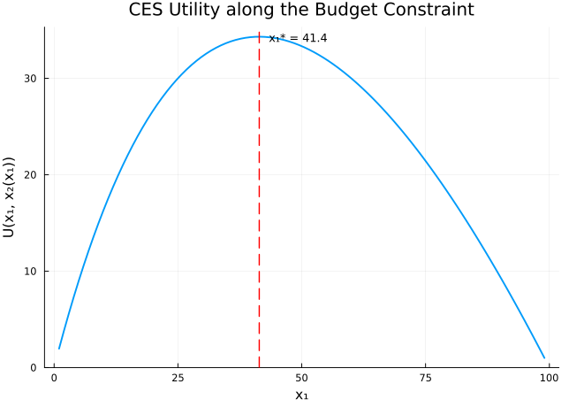

```julia
x1_grid = LinRange(1.0, 99.0, 100)                # 100 points between 1 and 99
utility = [-neg_utility(x1) for x1 in x1_grid]    # compute utility for each x1

plot(x1_grid, utility,
     xlabel = "x₁", ylabel = "U(x₁, x₂(x₁))",
     title = "CES Utility along the Budget Constraint",
     lw = 2, legend = false)
vline!([x1_star], ls = :dash, color = :red, lw = 1.5)
annotate!(x1_star + 2, maximum(utility) - 0.1,
          text("x₁* = $(round(x1_star, digits=1))", :left, 9))
```

The dashed red line marks the optimum found by `Optim`. The concavity of the CES utility function guarantees a unique interior maximum—the consumer balances spending across both goods.

## 9.3 Example: Short-Run Profit Maximization

Here is a second scalar optimization example. Consider a firm with Cobb-Douglas production $Y = A\bar{K}^{\alpha} L^{1-\alpha}$ that chooses labor $L$ in the short run, taking capital $\bar{K}$ as fixed. Revenue is $p \cdot Y$ and the only variable cost is the wage bill $wL$, so profit is:

$$\pi(L) = p \cdot A\, \bar{K}^{\alpha}\, L^{1-\alpha} - wL$$

Because $1-\alpha < 1$, the production function exhibits diminishing marginal returns to labor, which guarantees an interior optimum. We can verify this analytically: the first-order condition $p \cdot A\bar{K}^{\alpha}(1-\alpha)L^{-\alpha} = w$ gives $L^* = \bigl(\frac{p A \bar{K}^{\alpha}(1-\alpha)}{w}\bigr)^{1/\alpha}$. Let us confirm numerically:

```julia
function neg_profit(L; A=1.0, K̄=10.0, α=1/3, p=10.0, w=5.0)
    Y = A * K̄^α * L^(1-α)
    return -(p * Y - w * L)          # negate for minimization
end

result = optimize(neg_profit, 0.1, 1000.0)
L_star = Optim.minimizer(result)
println("Optimal labor: $(round(L_star, digits=2))")
println("Maximum profit: $(round(-Optim.minimum(result), digits=2))")
```

```
Optimal labor: 23.7
Maximum profit: 59.26
```

Notice that this is again a scalar problem, so we use `optimize(f, lower, upper)` with bounds that keep $L > 0$. The keyword arguments (`A=1.0`, `K̄=10.0`, etc.) set the model parameters as defaults, keeping the function signature clean for the optimizer while making the economics transparent.

**TipTips for Using Optim**

- **Optim minimizes.** To maximize $f(x)$, minimize $-f(x)$. Don’t forget to negate when interpreting the optimal function value!
- **Choice of algorithm matters.** The default Nelder-Mead is derivative-free and robust but slow. For smooth functions, gradient-based methods like `LBFGS()` are much faster. For scalar problems, `optimize(f, lower, upper)` uses Brent’s method, which is efficient and reliable.
- **Initial guess matters.** For multivariate problems, the optimizer starts from your initial guess and may find a local (not global) minimum. Try multiple starting points if you suspect multiple local minima.
- **Check convergence.** Use `Optim.converged(result)` to verify the optimizer successfully found a solution.

# 10 Broadcasting and Vectorized Operations

In the examples so far, most of our operations have acted on individual numbers—we wrote `x^2` to square a single value, or used a `for` loop to process each element of an array one at a time. But a huge amount of scientific computing involves applying the **same operation to every element** of an array. Julia provides a powerful mechanism for this called **broadcasting**, and understanding it will make your code both shorter and faster.

## 10.1 The Dot Syntax

Broadcasting in Julia uses the **dot syntax**: placing a `.` before (or after) an operator or function name tells Julia to apply the operation **element-wise** across arrays. For arithmetic operators, the dot goes before the operator:

```julia
x = [1.0, 2.0, 3.0, 4.0, 5.0]
y = x .^ 2          # Square each element
```

```
5-element Vector{Float64}:
  1.0
  4.0
  9.0
 16.0
 25.0
```

```julia
z = x .+ 10.0       # Add 10 to each element
```

```
5-element Vector{Float64}:
 11.0
 12.0
 13.0
 14.0
 15.0
```

```julia
w = x .* y           # Multiply corresponding elements
```

```
5-element Vector{Float64}:
   1.0
   8.0
  27.0
  64.0
 125.0
```

Without the dot, Julia would try to interpret `x + 10.0` as adding a scalar to a vector (which does work for `+` and `-` as a convenience), but `x * y` would attempt **matrix multiplication**, which is not defined for two vectors of the same shape. The dot syntax makes element-wise intent explicit and unambiguous.

For **functions**, the dot goes after the function name. This tells Julia to apply the function to each element of the input array individually:

```julia
log.(x)              # Natural log of each element
```

```
5-element Vector{Float64}:
 0.0
 0.6931471805599453
 1.0986122886681098
 1.3862943611198906
 1.6094379124341003
```

```julia
sqrt.(x)             # Square root of each element
```

```
5-element Vector{Float64}:
 1.0
 1.4142135623730951
 1.7320508075688772
 2.0
 2.23606797749979
```

You can even broadcast user-defined functions. Suppose you have a function `g(x) = x^2 + 3x - 1`. Writing `g.(x)` applies it to every element of `x`:

```julia
g(x) = x^2 + 3x - 1
g.(x)
```

```
5-element Vector{Float64}:
  3.0
  9.0
 17.0
 27.0
 39.0
```

This works for **any** function—built-in or user-defined. Julia automatically generates an efficient loop behind the scenes.

## 10.2 Why Broadcasting Matters

Broadcasting is not just a convenience—it can significantly improve **performance**. Consider two ways to compute $\log(c)$ for a vector of consumption levels. The first uses an explicit loop:

```julia
result = zeros(length(c))
for i in 1:length(c)
    result[i] = log(c[i])
end
```

The second uses broadcasting:

```julia
result = log.(c)
```

Both produce the same answer, but the broadcast version is typically faster. The reason is **memory allocation**. When you chain operations like `x .+ y .* z`, Julia **fuses** the broadcasts into a single loop: it computes the result element by element without creating intermediate temporary arrays. An explicit chain of operations like `temp = y .* z; result = x .+ temp` would allocate memory for `temp`, fill it in, and then allocate memory for `result`—two passes through memory instead of one. This fusion is automatic whenever you use dots, and it becomes increasingly important as arrays grow large.

## 10.3 Economic Application: Utility Over a Consumption Grid

A common task in computational economics is evaluating a utility function over a **grid** of consumption values. For example, when solving a consumption-savings problem, you might want to compute $u(c) = \log(c)$ for many possible consumption levels:

```julia
consumption = range(0.1, 10.0, length=100)    # 100 points from 0.1 to 10.0
utility_grid = log.(consumption)               # log utility for each level
```

```
100-element Vector{Float64}:
 -2.3025850929940455
 -1.6094379124341003
 -1.2039728043259361
 -0.916290731874155
 -0.6931471805599453
 -0.5108256237659907
 -0.35667494393873245
 -0.2231435513142097
 -0.10536051565782628
  0.0
  ⋮
  2.2192034840549946
  2.2300144001592104
  2.2407096892759584
  2.2512917986064953
  2.2617630984737906
  2.272125885509337
  2.2823823856765264
  2.2925347571405443
  2.302585092994046
```

```julia
using Plots
```

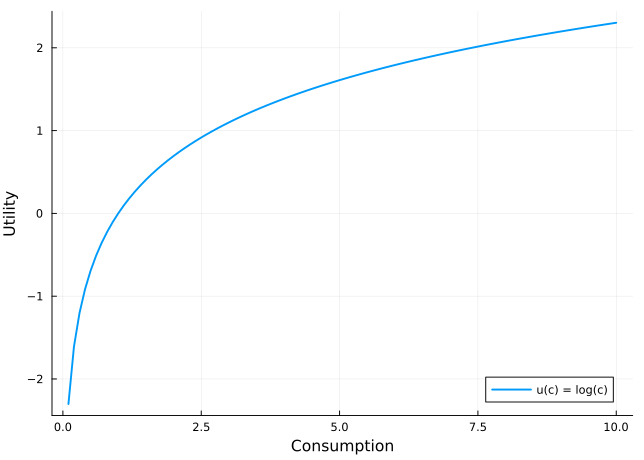

```julia
plot(collect(consumption), utility_grid, linewidth=2, label="u(c) = log(c)",
     xlabel="Consumption", ylabel="Utility", legend=:bottomright)
```

The concavity of the log function is clearly visible: the marginal utility of consumption falls as $c$ increases. This is the fundamental property that drives **risk aversion** and **consumption smoothing** in economic models. Broadcasting made it trivial to compute utility over the entire grid in a single expression.

## 10.4 Broadcasting with Multiple Arrays

Broadcasting also handles operations between arrays of different shapes. Julia’s rule is simple: dimensions are compatible if they are equal or if one of them is 1. A scalar is treated as an array with all dimensions equal to 1, so it broadcasts with anything.

For example, suppose you have a vector of wages $w$ and want to compute after-tax income for several tax rates $\tau$:

```julia
wages = [30_000.0, 50_000.0, 75_000.0, 100_000.0]
tax_rates = [0.10, 0.20, 0.30]

# Reshape tax_rates to a row vector so broadcasting gives a matrix
after_tax = wages .* (1 .- tax_rates')
```

```
4×3 Matrix{Float64}:
 27000.0  24000.0  21000.0
 45000.0  40000.0  35000.0
 67500.0  60000.0  52500.0
 90000.0  80000.0  70000.0
```

The result is a $4 \times 3$ matrix: each row corresponds to a wage level and each column to a tax rate. Julia automatically expanded the column vector of wages and the row vector of tax rates to produce every combination. This kind of “outer product” broadcasting is extremely useful for computing policy functions, transition matrices, and comparative statics grids.

**TipWhen to Use Broadcasting vs Loops**

**Use broadcasting** when you are applying the same operation to every element of an array, especially for simple mathematical transformations. It is concise, readable, and often faster due to loop fusion. **Use explicit loops** when the computation at step $t$ depends on the result from step $t-1$ (as in our AR(1) simulation), when the logic inside the loop involves complex branching, or when you need fine-grained control over the iteration. Both are perfectly idiomatic in Julia—the language is designed to make loops fast, so you never need to “vectorize for speed” the way you do in Python or R.

# 11 The Type System

Julia’s type system is one of the features that sets it apart from languages like Python and R. While those languages are “dynamically typed” in a way that hides types from the user, Julia makes types a central, visible part of the language. Understanding the type system is important for two reasons: it is the foundation of Julia’s **performance** (the compiler generates specialized machine code for each type combination), and it enables **multiple dispatch**, a powerful programming paradigm that makes code both flexible and fast.

## 11.1 Abstract and Concrete Types

Julia distinguishes between **abstract types** and **concrete types**. Concrete types are the types that actual values have—`Float64`, `Int64`, `Bool`, `String`. Every value in Julia has exactly one concrete type, and you can check it with `typeof`:

```julia
typeof(3.14)
```

```
Float64
```

```julia
typeof(42)
```

```
Int64
```

```julia
typeof(true)
```

```
Bool
```

Abstract types, on the other hand, cannot be instantiated directly. They exist to organize concrete types into a **hierarchy**. For example, `Number` is an abstract type that encompasses all numeric types. `Integer` is also abstract—it encompasses `Int64`, `Int32`, `UInt8`, and other integer types. You can think of the type hierarchy as a tree: abstract types are the interior nodes, and concrete types are the leaves.

## 11.2 The Type Hierarchy

You can explore the hierarchy with two built-in functions. `supertype` tells you a type’s parent in the hierarchy, and `subtypes` tells you its children:

```julia
supertype(Float64)
```

```
AbstractFloat
```

```julia
supertype(AbstractFloat)
```

```
Real
```

```julia
subtypes(Number)
```

```
4-element Vector{Any}:
 Base.MultiplicativeInverses.MultiplicativeInverse
 Complex
 Plots.Measurement
 Real
```

```julia
subtypes(Integer)
```

```
3-element Vector{Any}:
 Bool
 Signed
 Unsigned
```

The full path from `Float64` to the top of the hierarchy is `Float64 → AbstractFloat → Real → Number → Any`. Every type in Julia ultimately descends from `Any`, the root of the type tree. This hierarchy matters because functions can be defined to accept any type at a given level of the tree. A function that accepts `Number` will work with `Float64`, `Int64`, `BigFloat`, and any other numeric type.

## 11.3 Type Annotations

You can **annotate** function arguments with types using the `::` operator. This tells Julia (and the reader) what kinds of inputs the function expects:

```julia
function double(x::Number)
    return 2 * x
end
double(3.14)
```

```
6.28
```

```julia
double(42)
```

```
84
```

The annotation `x::Number` means this function accepts any numeric type—integers, floats, rationals, and so on. If you try to pass a non-numeric argument, Julia will raise an error:

```julia
double("hello")
```

```
MethodError: no method matching double(::String)
The function `double` exists, but no method is defined for this combination of argument types.

Closest candidates are:
  double(::Number)
   @ Main.Notebook ~/University of Oregon Dropbox/David Evans/University of Oregon/Courses/Spring 2026/EC 410/Lectures and Website/Julia/Basic Julia/JuliaBasicsNotes.qmd:1383

Stacktrace:
 [1] top-level scope
   @ ~/University of Oregon Dropbox/David Evans/University of Oregon/Courses/Spring 2026/EC 410/Lectures and Website/Julia/Basic Julia/JuliaBasicsNotes.qmd:1397
```

Type annotations on function arguments are **optional** in Julia. If you omit them, the function accepts any type (equivalent to annotating with `::Any`). All of the functions we have written so far omitted type annotations, and they worked fine. So why bother?

The answer is **multiple dispatch**: the ability to define different **methods** of the same function for different argument types.

## 11.4 Multiple Dispatch

Multiple dispatch is Julia’s core programming paradigm. The idea is simple: you can define several versions of a function with the same name but different type signatures, and Julia automatically selects the right version based on the types of the arguments at call time.

Here is an example with a `log_utility` function. The log utility of a single consumption level is a scalar computation, but the utility of a consumption vector requires element-wise application:

```julia
"""
    log_utility(c::Float64)

Compute log utility for a single consumption level.
"""
function log_utility(c::Float64)
    return log(c)
end

"""
    log_utility(c::Vector{Float64})

Compute log utility for a vector of consumption levels.
"""
function log_utility(c::Vector{Float64})
    return log.(c)
end
```

```
Main.Notebook.log_utility
```

Now Julia dispatches to the correct method automatically:

```julia
log_utility(2.5)                          # calls the scalar method
```

```
0.9162907318741551
```

```julia
log_utility([1.0, 2.0, 3.0, 4.0])        # calls the vector method
```

```
4-element Vector{Float64}:
 0.0
 0.6931471805599453
 1.0986122886681098
 1.3862943611198906
```

Each call goes to the version of `log_utility` whose type signature matches the argument. This is **multiple dispatch** in action: the same function name, but the behavior depends on the types of the inputs. Julia selects the most specific matching method at runtime.

You can see all the methods defined for a function using the `methods` function:

```julia
methods(log_utility)
```

# 2 methods for generic function **log_utility** from Main.Notebook:

- log_utility(c::**Vector{Float64}**) in Main.Notebook at /Users/devans/University of Oregon Dropbox/David Evans/University of Oregon/Courses/Spring 2026/EC 410/Lectures and Website/Julia/Basic Julia/JuliaBasicsNotes.qmd:1425

- log_utility(c::**Float64**) in Main.Notebook at /Users/devans/University of Oregon Dropbox/David Evans/University of Oregon/Courses/Spring 2026/EC 410/Lectures and Website/Julia/Basic Julia/JuliaBasicsNotes.qmd:1416

**ImportantWhy Julia’s Type System Enables Performance**

When you call `log_utility(2.5)`, Julia knows the argument is a `Float64`. The JIT (just-in-time) compiler generates **specialized machine code** for that specific type: it uses hardware floating-point instructions, avoids type checks, and produces code that runs as fast as hand-written C. When you call `log_utility([1.0, 2.0, 3.0, 4.0])`, Julia generates **different** specialized code optimized for `Vector{Float64}`. This is fundamentally different from Python, where the interpreter must check the type of every value at every operation. Julia’s approach—“write generic code, get specialized performance”—is the secret to its speed. You write high-level, readable code, and the compiler does the work of making it fast.

Multiple dispatch is pervasive in Julia. Operators like `+` and `*` are ordinary functions with hundreds of methods—one for adding two integers, one for adding two floats, one for adding a float and an integer, one for matrix multiplication, and so on. When you write `3.14 + 42`, Julia dispatches to a method that promotes the integer to a float and then performs floating-point addition. This is all happening behind the scenes, but it is the reason Julia can be both high-level and high-performance.

# 12 Worked Example: Simulating an AR(1) Process

Let us close these notes by combining everything we have learned—types, arrays, loops, functions, broadcasting, and plotting—into a complete worked example. We will simulate an **AR(1) process**, compute summary statistics, and compare them to the theoretical predictions. This example also serves as a preview of the Markov chain and dynamic programming tools we will use throughout the rest of the course.

## 12.1 The Model

An AR(1) (first-order autoregressive) process is defined by:

$$y_t = \rho \, y_{t-1} + \varepsilon_t, \qquad \varepsilon_t \sim \mathcal{N}(0, \sigma^2)$$

where $\rho \in (-1, 1)$ is the **persistence parameter** and $\sigma > 0$ is the **standard deviation of the innovation**. The process is **stationary** when $|\rho| < 1$, meaning it has a well-defined long-run distribution that does not depend on the initial condition. The unconditional (long-run) mean is $\mathbb{E}[y_t] = 0$, and the unconditional variance is:

$$\text{Var}(y_t) = \frac{\sigma^2}{1 - \rho^2}$$

This formula reveals an important economic intuition: as $\rho$ approaches 1, the variance explodes. Highly persistent processes wander widely because shocks accumulate rather than dissipating. When $\rho = 0$, the process is simply white noise with variance $\sigma^2$—each period is independent of the last.

AR(1) processes are the workhorse model in macroeconomics and finance. Log productivity in the RBC model follows an AR(1). Log income in life-cycle consumption models is typically AR(1). Interest rates, exchange rates, and inflation are all commonly modeled as AR(1) processes. Understanding the properties of this simple process is essential preparation for the dynamic models we will study later.

## 12.2 The Simulation Function

We already wrote a basic `simulateAR1` function in the Functions section. Here we extend it to include the innovation standard deviation $\sigma$ as a parameter and use a named tuple to return both the simulated path and the parameter values:

```julia
using Random

"""
    simulate_ar1(ρ, σ, T; y0=0.0)

Simulate `T` periods of the AR(1) process yₜ = ρ yₜ₋₁ + σ εₜ
where εₜ ~ N(0, 1).

# Arguments
- `ρ`: persistence parameter (must satisfy |ρ| < 1 for stationarity)
- `σ`: standard deviation of innovations
- `T`: number of periods to simulate
- `y0`: initial value (default 0.0)

# Returns
- Named tuple `(path, ρ, σ)` containing the simulated path and parameters
"""
function simulate_ar1(ρ::Float64, σ::Float64, T::Int; y0::Float64=0.0)
    y = zeros(T)
    y[1] = y0
    for t in 2:T
        y[t] = ρ * y[t-1] + σ * randn()
    end
    return (path = y, ρ = ρ, σ = σ)
end
```

```
Main.Notebook.simulate_ar1
```

A few things to note about this function. First, it uses **type annotations** (`ρ::Float64`, `T::Int`) to make the expected inputs explicit. Second, it **pre-allocates** the output array with `zeros(T)` for efficiency. Third, it returns a **named tuple** so the caller can access both the simulated data and the parameters that generated it. Fourth, the loop is unavoidable here: each value $y_t$ depends on the previous value $y_{t-1}$, so we cannot use broadcasting.

## 12.3 Simulating and Plotting

Let us simulate a single path with $\rho = 0.9$, $\sigma = 0.5$, and $T = 200$ periods:

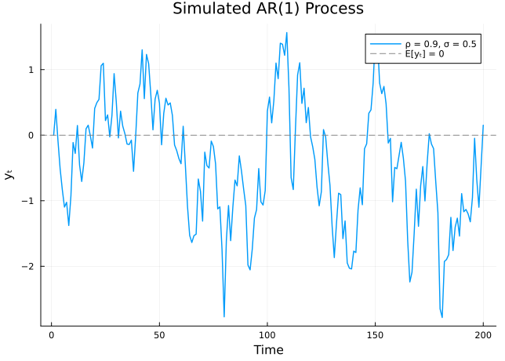

```julia
Random.seed!(42)    # Set seed for reproducibility
result = simulate_ar1(0.9, 0.5, 200)

plot(result.path, linewidth=1.5, label="ρ = $(result.ρ), σ = $(result.σ)",
     xlabel="Time", ylabel="yₜ", title="Simulated AR(1) Process",
     legend=:topright)
hline!([0.0], linestyle=:dash, color=:gray, label="E[yₜ] = 0")
```

The series fluctuates around its unconditional mean of zero, but because $\rho = 0.9$ is high, the deviations are persistent—the series drifts above or below zero for extended stretches before reverting. This is exactly the kind of behavior we see in macroeconomic time series like detrended GDP or the unemployment rate.

Now let us compare paths with different levels of persistence. Setting the same random seed for each simulation ensures the underlying shocks $\varepsilon_t$ are identical, so any differences in the paths are due entirely to the persistence parameter:

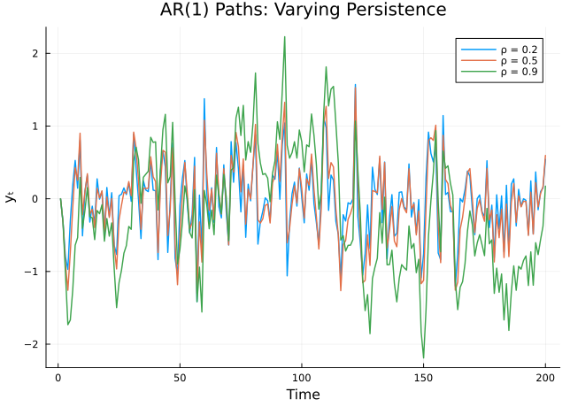

```julia
plot(title="AR(1) Paths: Varying Persistence", xlabel="Time", ylabel="yₜ")
for ρ in [0.2, 0.5, 0.9]
    Random.seed!(123)
    sim = simulate_ar1(ρ, 0.5, 200)
    plot!(sim.path, linewidth=1.5, label="ρ = $ρ")
end
plot!()
```

The visual difference is striking. The low-persistence path ($\rho = 0.2$) bounces rapidly around zero—shocks die out within a few periods. The high-persistence path ($\rho = 0.9$) exhibits long, slow swings that resemble business cycles. The persistence parameter $\rho$ is doing all the work: the same sequence of shocks produces dramatically different dynamics depending on how quickly those shocks dissipate.

## 12.4 Comparing Sample and Theoretical Moments

The theory predicts that the unconditional variance of a stationary AR(1) process is $\sigma^2 / (1 - \rho^2)$. With a long enough simulation, the sample variance should be close to this theoretical value. Let us check with a simulation of $T = 100{,}000$ periods:

```julia
using Statistics

Random.seed!(999)
ρ, σ = 0.9, 0.5
long_sim = simulate_ar1(ρ, σ, 100_000)

theoretical_var = σ^2 / (1 - ρ^2)
sample_var = var(long_sim.path)

println("Theoretical variance: $(round(theoretical_var, digits=4))")
println("Sample variance:      $(round(sample_var, digits=4))")
println("Theoretical mean:     0.0")
println("Sample mean:          $(round(mean(long_sim.path), digits=4))")
```

```
Theoretical variance: 1.3158
Sample variance:      1.2946
Theoretical mean:     0.0
Sample mean:          -0.0088
```

With 100,000 observations, the sample moments are very close to their theoretical counterparts. This convergence is a consequence of the **law of large numbers**: as the sample size grows, sample averages converge to population means. The small remaining discrepancy is simply sampling variation—it would shrink further with even more observations.

**TipConnection to Markov Chains**

The AR(1) process is a **continuous-state** Markov process: the distribution of $y_{t+1}$ depends only on $y_t$, not on any earlier history. In the next set of lectures, we will study **discrete-state** Markov chains, where the state variable takes on a finite number of values and transitions are governed by a matrix $P$. A key technique in computational economics is **discretizing** continuous AR(1) processes into finite Markov chains using methods like Tauchen (1986) or Rouwenhorst (1995). This lets us apply the powerful matrix algebra tools of Markov chains to problems that are naturally continuous, like the RBC model’s productivity process.

# 13 Summary

In these notes we covered the essential building blocks of Julia programming:

**Primitive data types** form the foundation. Booleans (`true`/`false`) represent logical values. Integers (`Int64`) represent whole numbers. Floating-point numbers (`Float64`) represent real-valued quantities with decimal precision. Strings (`String`) represent text, with powerful interpolation and manipulation capabilities.

**Container types** let us organize data into collections:

- **Arrays** (`Vector`) are ordered and mutable—the go-to choice for most numerical work.
- **Tuples** are ordered and immutable—useful for fixed collections and function return values.
- **Named tuples** add descriptive labels to immutable data.
- **Dictionaries** (`Dict`) provide key-value lookup for labeled data.

**Control flow** gives our programs the ability to make decisions and repeat operations:

- **For loops** iterate over ranges and collections.
- **Comparisons** (`<`, `>`, `==`, `!=`, `<=`, `>=`) produce boolean values.
- **Logical operators** (`&&`, `||`, `!`) combine boolean expressions.
- **If statements** execute code conditionally.

**Functions** let us package reusable code into named units:

- **Anonymous functions** (`x -> x^2`) for quick, throwaway operations.
- **Short-form** (`f(x) = x^2`) for simple named functions.
- **Multi-line** (`function ... end`) for complex logic with `return`.
- **Default arguments** make parameters optional.
- **Docstrings** provide built-in documentation.

**Root solving** with `NonlinearSolve.jl` lets us find values $x^*$ where $f(x^*) = 0$:

- Define `f(u, p)` and create a `NonlinearProblem(f, u0)`.
- Solve with `sol = solve(prob)` and read the answer from `sol.u`.
- Applications include CES market equilibrium and solving systems of nonlinear equations.

**Optimization** with `Optim.jl` lets us maximize and minimize functions:

- `Optim.jl` **minimizes** by default—negate your function to maximize.
- For scalar functions: `optimize(f, lower, upper)`.
- For multivariate functions: `optimize(f, x0)`.
- Use `Optim.minimizer(result)` and `Optim.minimum(result)` to extract solutions.

**Broadcasting** lets us apply operations element-wise to entire arrays using the dot syntax (`.+`, `.*`, `f.(x)`), with automatic loop fusion for performance.

**The type system** organizes Julia’s types into a hierarchy of abstract and concrete types. Type annotations and **multiple dispatch** let you define different methods of the same function for different argument types, and the JIT compiler generates specialized machine code for each type combination.

**The AR(1) worked example** tied everything together: we wrote a typed, documented simulation function, plotted paths with varying persistence, and confirmed that sample moments converge to their theoretical values—previewing the Markov chain tools we will use throughout the course.

**ImportantKey Things to Remember**

- Julia is **1-indexed**: the first element of an array is `L[1]`, and `L[end]` gives the last element.
- Functions ending with `!` (like `push!`) modify their arguments in place.
- You can use **Greek letters** and other Unicode characters as variable names.
- Use **typed arrays** when possible for better performance.
- **Pre-allocate arrays** (e.g., `zeros(T)`) rather than growing them with `push!` in performance-sensitive code.
- **Broadcasting** with dot syntax (e.g., `log.(x)`, `x .+ y`) applies operations element-wise and fuses loops for performance.
- **Multiple dispatch** selects the right function method based on argument types—use type annotations to define specialized methods.
- `NonlinearSolve` functions use the `f(u, p)` signature; always check `sol.retcode`.
- When using `Optim`, remember it **minimizes**—negate to maximize.

With these fundamentals in hand, you are ready to move on to more advanced topics like working with matrices, Markov chains, and tackling dynamic economic models in Julia.